# assignment2

## 20182479 목지윤

### 1. 먼저 ID와 ZIP.code는 feature에서 제외한다. 그리고 z-score normalization을 활용하여 모든 feature들의 scale을 일치시킨다. 첫 4,000명의 데이터를 training set으로, 나머지 1,000명의 데이터를 test set으로 사용하고, training set과 test set에서의 target variable의 분포를 비교해 보자.

```r
#사용할 패키지 설치
library(caret)
```

```r
library(ggplot2)
library(class)
#데이터 읽어오기
cb<-read.csv('CommonBank.csv',stringsAsFactors=FALSE)

#ID,ZIP.code는 feature에서 제외
cb<-cb[c(-1,-5)]
str(cb)
```

```
## 'data.frame':    5000 obs. of  12 variables:
##  $ Age              : int  25 45 39 35 35 37 53 50 35 34 ...
##  $ Experience       : int  1 19 15 9 8 13 27 24 10 9 ...
##  $ Income           : int  49 34 11 100 45 29 72 22 81 180 ...
##  $ Family           : int  4 3 1 1 4 4 2 1 3 1 ...
##  $ CCAvg            : num  1.6 1.5 1 2.7 1 0.4 1.5 0.3 0.6 8.9 ...
##  $ Education        : int  1 1 1 2 2 2 2 3 2 3 ...
##  $ Mortgage         : int  0 0 0 0 0 155 0 0 104 0 ...
##  $ PersonalLoan     : int  0 0 0 0 0 0 0 0 0 1 ...
##  $ SecuritiesAccount: int  1 1 0 0 0 0 0 0 0 0 ...
##  $ CDAccount        : int  0 0 0 0 0 0 0 0 0 0 ...
##  $ Online           : int  0 0 0 0 0 1 1 0 1 0 ...
##  $ CreditCard       : int  0 0 0 0 1 0 0 1 0 0 ...
```

```r
#target변수 PersonalLoan 자료형 factor로 바꾸기
cb$PersonalLoan<-factor(cb$PersonalLoan,levels=c(1,0),labels=c("Accpet","Reject"))

#z_score normalization
cb[,-8]<-scale(cb[,-8])

#training set과 test set 나누기
cb_train<-cb[1:4000,]
cb_test<-cb[4001:5000,]
cb_train_label<-cb[1:4000,8]
cb_test_label<-cb[4001:5000,8]
```

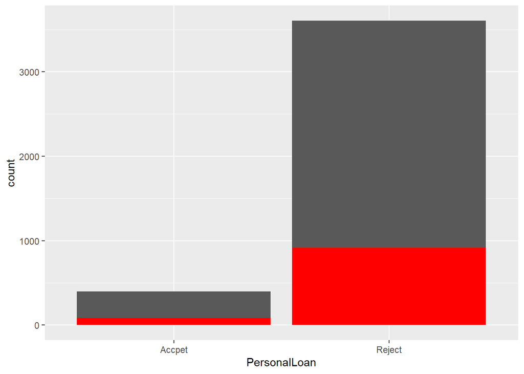

```r
#target variable 분포 그래프
ggplot(cb_train,mapping=aes(PersonalLoan)) + geom_bar() + geom_bar(cb_test,mapping=aes(PersonalLoan),fill="red")
```

#### test set(red), train set(black)의 target variable 분포가 1:9 정도로 비슷하다.

### 2. 5-NN을 적용하고, 결과를 분석해보자.

#### ● knn 모델 만들기

```r
# target variable을 제외한 train, test set
cb_train_feature<-cb[1:4000,-8]
cb_test_feature<-cb[4001:5000,-8]
# 5-NN model
set.seed(11)
knn_model<-knn(train=cb_train_feature,test=cb_test_feature,cl=cb_train_label,k=5)
```

```r
# test set의 target variable과 결과 비교
table(cb_test_label,knn_model)
```

```
##              knn_model
## cb_test_label Accpet Reject
##        Accpet     49     34
##        Reject      4    913
```

### 3. Training set 중에서 마지막 800명의 데이터를 validation set으로 사용하여, 다양한 k 값에 대해 k-NN을 적용해 보고 예측 성능을 비교해 보자. k가 어떤 값을 가질때 모델의 성능이 가장 우수한가?

```r
#validation set
cb_valid<-cb[3201:4000,]
cb_valid_feature<-cb[3201:4000,-8]
cb_valid_label<-cb[3201:4000,8]
train<-cb[1:3200,]
train_feature<-cb[1:3200,-8]
train_label<-cb[1:3200,8]
```

```r
#knn 학습하기
#target variable이 범주형이므로 k값은 홀수로 하는것이 적합하다
accuracy<-NULL
for (i in seq(1,30,2)) {
  set.seed(11)
  knn_fit<-knn(train=train_feature,test=cb_valid_feature,cl=train_label,k=i)
  accuracy<- c(accuracy, sum(knn_fit == cb_valid_label) / length(cb_valid_label))
}
accuracy
```

```
##  [1] 0.95750 0.94750 0.95250 0.94500 0.94625 0.93875 0.93625 0.93500 0.93375
## [10] 0.93625 0.93625 0.93375 0.93250 0.93250 0.93000
```

#### k=1에서 정확도가 가장 높다. 하지만 k=1일 경우 과적합의 위험이 있으므로 두번째로 정확도가 높은 k=5이 적합하다.

### 4. Training set에 대해 5-fold cross validation을 5회 반복하여 best k 값을 찾아보자. Best k 값으로 만들어지는 최종 model에 test set을 적용하여 model의 성능을 report하자.

```r
set.seed(11)
#5_fold cross validation 을 5회 반복
cv<-trainControl(method="repeatedcv",number=5,repeats=5)

#k=1..20 값에 대해서 parameter tuning
tune_grid<-expand.grid(k=c(1:20))

#모델을 학습하는 train() 함수 이용
model_fit<-train(data=cb_train,PersonalLoan~.,method="knn",trControl=cv,tuneGrid=tune_grid)
model_fit
```

```
## k-Nearest Neighbors
##
## 4000 samples
##   11 predictor
##    2 classes: 'Accpet', 'Reject'
##
## No pre-processing
## Resampling: Cross-Validated (5 fold, repeated 5 times)
## Summary of sample sizes: 3201, 3200, 3200, 3200, 3199, 3200, ...
## Resampling results across tuning parameters:
##
##   k   Accuracy   Kappa
##    1  0.9545500  0.7213882
##    2  0.9494003  0.6865800
##    3  0.9575000  0.7233290
##    4  0.9540995  0.6956953
##    5  0.9556495  0.7020868
##    6  0.9534995  0.6861684
##    7  0.9530992  0.6784386
##    8  0.9511990  0.6618429
##    9  0.9499492  0.6498816
##   10  0.9488000  0.6415189
##   11  0.9496997  0.6482282
##   12  0.9478995  0.6334876
##   13  0.9463493  0.6202346
##   14  0.9456491  0.6138451
##   15  0.9449993  0.6075919
##   16  0.9440494  0.6001073
##   17  0.9435990  0.5964989
##   18  0.9423990  0.5845926
##   19  0.9428493  0.5880440
##   20  0.9415488  0.5767955
##
## Accuracy was used to select the optimal model using the largest value.
## The final value used for the model was k = 3.
```

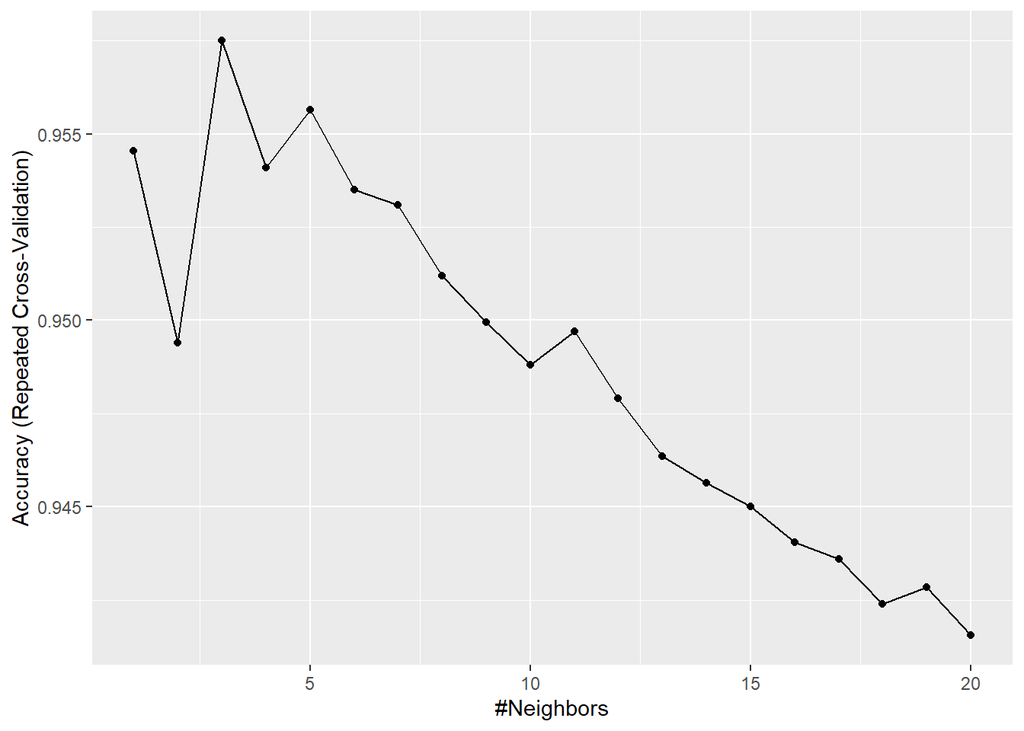

```r
# k값에 따른 정확도 그래프
ggplot(model_fit)
```

#### k=3일 때 accuracy가 0.9575로 가장 높기 때문에 Best k값은 3이다.

#### ● 최종 model을 test set에 적용

```r
test_pred<-predict(model_fit,cb_test)
confusionMatrix(test_pred,cb_test_label)
```

```
## Confusion Matrix and Statistics
##
##           Reference
## Prediction Accpet Reject
##     Accpet     54      4
##     Reject     29    913
##
##                Accuracy : 0.967
##                  95% CI : (0.954, 0.9772)
##     No Information Rate : 0.917
##     P-Value [Acc > NIR] : 9.350e-11
##
##                   Kappa : 0.7488
##
##  Mcnemar's Test P-Value : 2.943e-05
##
##             Sensitivity : 0.6506
##             Specificity : 0.9956
##          Pos Pred Value : 0.9310
##          Neg Pred Value : 0.9692
##              Prevalence : 0.0830
##          Detection Rate : 0.0540
##    Detection Prevalence : 0.0580
##       Balanced Accuracy : 0.8231
##
##        'Positive' Class : Accpet
##
```

#### accuracy=0.967, sensitivity=0.6506, specificity=0.9956

### 5. 3번과 4번에서 활용한 training 방식의 장단점을 비교해보자.

#### 4번에서 사용한 k-fold cross validation은 모든 데이터셋을 훈련, 평가에 활용 할 수 있어 정확도를 향상 시키고 데이터 부족으로 인한 underfitting을 막을 수 있다. 또한, 평가에 사용되는 데이터 편중을 막을 수 있으며 좀 더 일반화된 모델을 만들 수 있다는 장점이 있지만 iteration 횟수가 많기 때문에 모델 훈련 및 평가 시간이 오래 걸린다.

#### 그에 비해 3번에서 validation set을 사용하면 모델의 성능을 빠르게 평가 할 수 있다. 하지만 validation set을 하나만 정해서 한번 사용하므로 데이터의 양이 많지 않을 경우에는 신뢰하기 어렵고 변동이 커질수 있으며 모델의 성능이 validation set을 어떤것으로 정하느냐에따라 달라지게 된다.